# Compare cluster assignemnt and persistent colonization across variant calling approaches

Kyle Gontjes

2026-10-06

# Environment

```r
#Packages
packages <- c("tidyverse",'ggraph','igraph','kableExtra','pbmcapply')

#Load Packages
invisible(lapply(packages,library,character.only=T,quietly=T))

#Source functions
source("./lib/common_functions.R")
source("./lib/consistent_themes.R")

# Print environment
set.seed(45)
Sys.info()
```

```
                                                                                                         sysname
                                                                                                        "Darwin"
                                                                                                         release
                                                                                                        "25.6.0"
                                                                                                         version
"Darwin Kernel Version 25.6.0: Tue Aug 18 17:51:47 PDT 2026; root:xnu-12377.161.15.700.19~2/RELEASE_ARM64_T6050"
                                                                                                        nodename
                                                                             "mac-k76xf3g5yq.wifi.med.umich.edu"
                                                                                                         machine
                                                                                                         "arm64"
                                                                                                           login
                                                                                                          "root"
                                                                                                            user
                                                                                                      "kgontjes"
                                                                                                  effective_user
                                                                                                      "kgontjes"
```

# Load dataset

```r
df <- readRDS("./data/dataset/MERLIN_cohort_metadata_final.RDS") %>% subset(qc_pass==T & WGS_escre==T)
df_index <- readRDS("./data/dataset/MERLIN_cohort_index_cases_metadata_final.RDS")
```

## Cluster assignments across full dataset

1. This looks at cluster assignments across the full dataset.
2. As you can see, there is anice plateau of adjusted Rand Index and pairwise concordance when comparing SNP threshold choice in old (concatenated internal genomes) and new (public closed chromosome references) around 20-25 SNPs!
3. Difference at 18 SNPs is miniscule, just a loner singleton that got grouped into a cluster later (20 SNP in old dataset vs. 15 in new dataset)

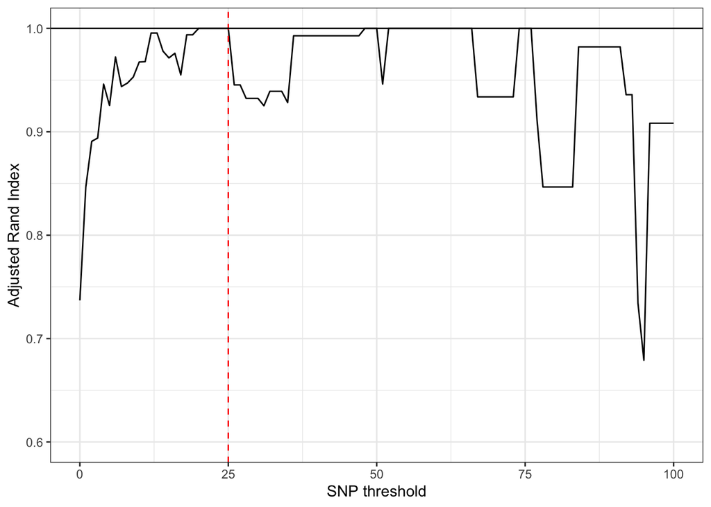

```r
clustering_across_thresholds_old <- readRDS('./data/SNP_distances/deprecated/SNP_cluster_assignments/MERLIN_SNP_cluster_assignments_concatenated_references.RDS') %>% mutate(test = "Concatenated reference")
clustering_across_thresholds_ST_preferred <- readRDS('./data/SNP_distances/SNP_cluster_assignments/MERLIN_SNP_cluster_assignments_public_references.RDS')%>% mutate(test = "Public reference")

similarity_dataset <- lapply(0:100, FUN = function(x) {
    col_name <- paste0("Species_ST_cluster_", x)

    SNP_clustering <- clustering_across_thresholds_old %>%
        select(genomic_id, all_of(col_name)) %>%
        rename(!!paste0(col_name, "_old") := all_of(col_name)) %>%
        left_join(
            clustering_across_thresholds_ST_preferred %>%
                select(genomic_id, all_of(col_name)) %>%
                rename(!!paste0(col_name, "_ST_preferred") := all_of(col_name))
        )

    old_clusters <- SNP_clustering[[paste0(col_name, "_old")]]
    new_clusters <- SNP_clustering[[paste0(col_name, "_ST_preferred")]]

    co_cluster_old <- outer(old_clusters, old_clusters, "==")
    co_cluster_new <- outer(new_clusters, new_clusters, "==")
    agree_mat      <- (co_cluster_old == co_cluster_new)[lower.tri(co_cluster_old)]

    data.frame(
        threshold            = x,
        ARI                  = mclust::adjustedRandIndex(old_clusters, new_clusters),
        pairwise_concordance = mean(agree_mat),
        n_discordant_pairs   = sum(!agree_mat),
        isolates             = nrow(SNP_clustering)
    )
}) %>%
    bind_rows()

lowerARI <- floor(min(similarity_dataset$ARI) / 0.1) * 0.1  # round down to nearest 0.1
lower_pc <- floor(min(similarity_dataset$pairwise_concordance) / 0.01) * 0.01  # round down to nearest 0.01

A_full <- ggplot(data=similarity_dataset,aes(x=threshold,y=ARI)) + geom_line() + geom_vline(xintercept = 25,linetype = 2,colour = 'red') + theme_bw() + labs(x='SNP threshold',y='Adjusted Rand Index') + geom_hline(yintercept = 1) +  scale_y_continuous(
  limits = c(lowerARI, 1.0),
  breaks = seq(lowerARI, 1.0, by = 0.1)
)
A_full
```

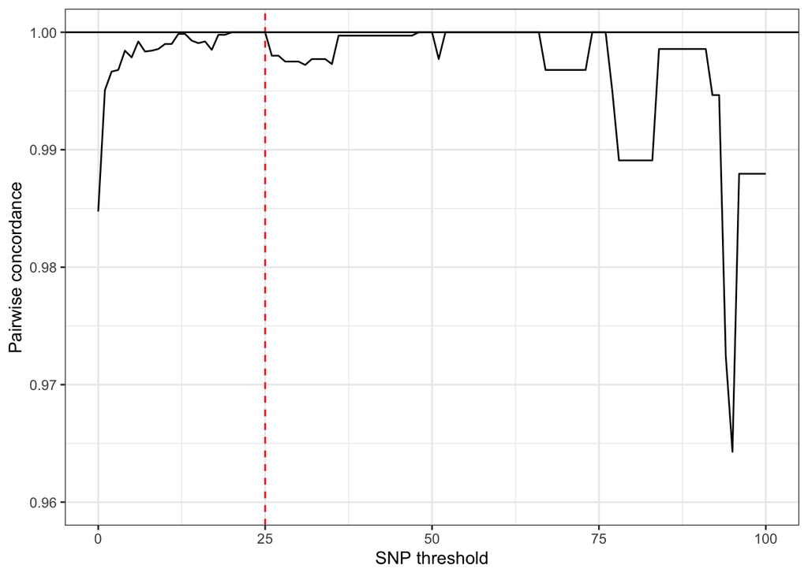

```r
B_full <- ggplot(data=similarity_dataset,aes(x=threshold,y=pairwise_concordance)) + geom_line() + geom_vline(xintercept = 25,linetype = 2,colour = 'red') + theme_bw() + labs(x='SNP threshold',y='Pairwise concordance') + ylim(0,1.01) +  geom_hline(yintercept = 1) + scale_y_continuous(
  limits = c(lower_pc, 1.0),
  breaks = seq(lower_pc, 1.0, by = 0.01)
)
B_full
```

```r
paste0("Agreement in clusteirng across variant calling strategies for the full dataset")
```

```
[1] "Agreement in clusteirng across variant calling strategies for the full dataset"
```

```r
similarity_dataset %>% favorite_kable()
```

| threshold | ARI | pairwise_concordance | n_discordant_pairs | isolates |
| --- | --- | --- | --- | --- |
| 0 | 0.7369507 | 0.9847448 | 214 | 168 |
| 1 | 0.8465153 | 0.9950813 | 69 | 168 |
| 2 | 0.8907488 | 0.9966496 | 47 | 168 |
| 3 | 0.8939674 | 0.9967921 | 45 | 168 |
| 4 | 0.9460649 | 0.9984317 | 22 | 168 |
| 5 | 0.9253856 | 0.9978614 | 30 | 168 |
| 6 | 0.9723070 | 0.9992159 | 11 | 168 |
| 7 | 0.9437463 | 0.9983604 | 23 | 168 |
| 8 | 0.9470721 | 0.9984317 | 22 | 168 |
| 9 | 0.9529798 | 0.9985743 | 20 | 168 |
| 10 | 0.9675299 | 0.9990020 | 14 | 168 |
| 11 | 0.9678191 | 0.9990020 | 14 | 168 |
| 12 | 0.9955223 | 0.9998574 | 2 | 168 |
| 13 | 0.9955223 | 0.9998574 | 2 | 168 |
| 14 | 0.9779926 | 0.9992871 | 10 | 168 |
| 15 | 0.9714512 | 0.9990733 | 13 | 168 |
| 16 | 0.9759455 | 0.9992159 | 11 | 168 |
| 17 | 0.9550281 | 0.9985030 | 21 | 168 |
| 18 | 0.9938060 | 0.9997861 | 3 | 168 |
| 19 | 0.9938060 | 0.9997861 | 3 | 168 |
| 20 | 1.0000000 | 1.0000000 | 0 | 168 |
| 21 | 1.0000000 | 1.0000000 | 0 | 168 |
| 22 | 1.0000000 | 1.0000000 | 0 | 168 |
| 23 | 1.0000000 | 1.0000000 | 0 | 168 |
| 24 | 1.0000000 | 1.0000000 | 0 | 168 |
| 25 | 1.0000000 | 1.0000000 | 0 | 168 |
| 26 | 0.9453462 | 0.9980040 | 28 | 168 |
| 27 | 0.9453462 | 0.9980040 | 28 | 168 |
| 28 | 0.9323200 | 0.9975050 | 35 | 168 |
| 29 | 0.9323200 | 0.9975050 | 35 | 168 |

[output cut: 71 more lines]

## Clustering statistics across full dataset

1. As mentioned above, clustering is the same when comparing old and new data across the 20-25 SNPs thresholds
2. In 16-19 SNP threshold, the number of cluster isolates is more in the new dataset (likely because we used a better reference genome!) This is resolved at 20 SNP threshold.

```r
clustering_across_threshold <- pbmclapply(0:100,FUN=function(x){
  old <-cluster_summary_statistics(clustering_across_thresholds_old[[paste0("Species_ST_cluster_",x)]]) %>% mutate(type = 'old',threshold=x)
  new <- cluster_summary_statistics(clustering_across_thresholds_ST_preferred[[paste0("Species_ST_cluster_",x)]]) %>% mutate(type = 'new',threshold=x)
  rbind.data.frame(old,new )


},mc.cores=15) %>% do.call(rbind,.)

numeric_cols <- c("clusters", "cluster_isolates", "singletons", "percentage_in_cluster",
                  "cluster_size_med", "cluster_size_mean", "cluster_size_max")

old_df <- clustering_across_threshold %>% filter(type == "old") %>% arrange(threshold)
new_df <- clustering_across_threshold %>% filter(type == "new") %>% arrange(threshold)

diff_df <- new_df[numeric_cols] - old_df[numeric_cols]
diff_df$threshold <- old_df$threshold
diff_df$type <- "diff (new - old)"
diff_df$same_clustering_statistics <- rowSums(abs(diff_df[numeric_cols])) == 0
diff_df <- diff_df %>% select(threshold, same_clustering_statistics, everything())

diff_df  %>% favorite_kable()
```

| threshold | same_clustering_statistics | clusters | cluster_isolates | singletons | percentage_in_cluster | cluster_size_med | cluster_size_mean | cluster_size_max | type |
| --- | --- | --- | --- | --- | --- | --- | --- | --- | --- |
| 0 | FALSE | 4 | 9 | -9 | 5.3571429 | 0.0 | -0.0755149 | 0 | diff (new - old) |
| 1 | FALSE | 4 | 9 | -9 | 5.3571429 | -1.0 | -0.1015532 | 1 | diff (new - old) |
| 2 | FALSE | 2 | 8 | -8 | 4.7619048 | 0.5 | 0.0500000 | 0 | diff (new - old) |
| 3 | FALSE | 0 | 3 | -3 | 1.7857143 | 0.0 | 0.0909091 | 0 | diff (new - old) |
| 4 | FALSE | 2 | 5 | -5 | 2.9761905 | 0.0 | -0.0510823 | 0 | diff (new - old) |
| 5 | FALSE | 0 | 3 | -3 | 1.7857143 | 0.0 | 0.0857143 | 0 | diff (new - old) |
| 6 | FALSE | -1 | 0 | 0 | 0.0000000 | 0.0 | 0.0960317 | 0 | diff (new - old) |
| 7 | TRUE | 0 | 0 | 0 | 0.0000000 | 0.0 | 0.0000000 | 0 | diff (new - old) |
| 8 | FALSE | 1 | -1 | 1 | -0.5952381 | -0.5 | -0.1319328 | 0 | diff (new - old) |
| 9 | FALSE | 1 | 3 | -3 | 1.7857143 | 0.5 | -0.0176471 | 0 | diff (new - old) |
| 10 | FALSE | 2 | 3 | -3 | 1.7857143 | 0.0 | -0.1272727 | 0 | diff (new - old) |
| 11 | FALSE | 1 | 1 | -1 | 0.5952381 | 0.0 | -0.0773109 | 0 | diff (new - old) |
| 12 | FALSE | 0 | 1 | -1 | 0.5952381 | 0.0 | 0.0294118 | 0 | diff (new - old) |
| 13 | FALSE | 0 | 1 | -1 | 0.5952381 | 0.0 | 0.0294118 | 0 | diff (new - old) |
| 14 | FALSE | 1 | 1 | -1 | 0.5952381 | 0.0 | -0.0828877 | 0 | diff (new - old) |
| 15 | TRUE | 0 | 0 | 0 | 0.0000000 | 0.0 | 0.0000000 | 0 | diff (new - old) |
| 16 | FALSE | 1 | 1 | -1 | 0.5952381 | 0.0 | -0.0798319 | 0 | diff (new - old) |
| 17 | FALSE | 0 | 1 | -1 | 0.5952381 | 0.0 | 0.0294118 | 0 | diff (new - old) |
| 18 | FALSE | 0 | 1 | -1 | 0.5952381 | 0.0 | 0.0303030 | 0 | diff (new - old) |
| 19 | FALSE | 0 | 1 | -1 | 0.5952381 | 0.0 | 0.0303030 | 0 | diff (new - old) |
| 20 | TRUE | 0 | 0 | 0 | 0.0000000 | 0.0 | 0.0000000 | 0 | diff (new - old) |
| 21 | TRUE | 0 | 0 | 0 | 0.0000000 | 0.0 | 0.0000000 | 0 | diff (new - old) |
| 22 | TRUE | 0 | 0 | 0 | 0.0000000 | 0.0 | 0.0000000 | 0 | diff (new - old) |
| 23 | TRUE | 0 | 0 | 0 | 0.0000000 | 0.0 | 0.0000000 | 0 | diff (new - old) |
| 24 | TRUE | 0 | 0 | 0 | 0.0000000 | 0.0 | 0.0000000 | 0 | diff (new - old) |
| 25 | TRUE | 0 | 0 | 0 | 0.0000000 | 0.0 | 0.0000000 | 0 | diff (new - old) |
| 26 | FALSE | 1 | 0 | 0 | 0.0000000 | 0.0 | -0.1231061 | -2 | diff (new - old) |
| 27 | FALSE | 1 | 0 | 0 | 0.0000000 | 0.0 | -0.1231061 | -2 | diff (new - old) |
| 28 | FALSE | 1 | -1 | 1 | -0.5952381 | 0.0 | -0.1543561 | -2 | diff (new - old) |
| 29 | FALSE | 1 | -1 | 1 | -0.5952381 | 0.0 | -0.1543561 | -2 | diff (new - old) |

[output cut: 71 more lines]

# Cluster assignment among index specimens

1. Again, clustering assignments are the same from 20-25 SNP threshold

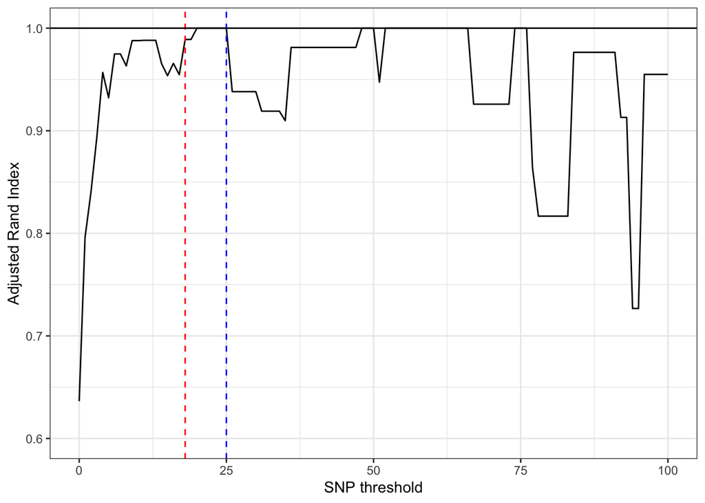

```r
similarity_dataset_index <- lapply(0:100, FUN = function(x) {
    col_name <- paste0("Species_ST_cluster_", x)

    SNP_clustering <- clustering_across_thresholds_old %>%
        select(genomic_id, all_of(col_name)) %>%
        rename(!!paste0(col_name, "_old") := all_of(col_name)) %>%
        left_join(
            clustering_across_thresholds_ST_preferred %>%
                select(genomic_id, all_of(col_name)) %>%
                rename(!!paste0(col_name, "_ST_preferred") := all_of(col_name))
        ) %>% subset(genomic_id %in% df_index$genomic_id)

    old_clusters <- SNP_clustering[[paste0(col_name, "_old")]]
    new_clusters <- SNP_clustering[[paste0(col_name, "_ST_preferred")]]

    co_cluster_old <- outer(old_clusters, old_clusters, "==")
    co_cluster_new <- outer(new_clusters, new_clusters, "==")
    pair_concordance <- mean((co_cluster_old == co_cluster_new)[lower.tri(co_cluster_old)])

    data.frame(
        threshold        = x,
        ARI              = mclust::adjustedRandIndex(old_clusters, new_clusters),
        pairwise_concordance = pair_concordance,
        isolates = nrow(SNP_clustering)
    )
}) %>%
    bind_rows()

lowerARI <- floor(min(similarity_dataset_index$ARI) / 0.1) * 0.1  # round down to nearest 0.1
lower_pc <- floor(min(similarity_dataset_index$pairwise_concordance) / 0.01) * 0.01  # round down to nearest 0.01

A <- ggplot(data=similarity_dataset_index,aes(x=threshold,y=ARI)) + geom_line() + geom_vline(xintercept = 18,linetype = 2,colour = 'red') + geom_vline(xintercept = 25,linetype = 2,colour = 'blue') + theme_bw() + labs(x='SNP threshold',y='Adjusted Rand Index') + geom_hline(yintercept = 1) +  scale_y_continuous(
  limits = c(lowerARI, 1.0),
  breaks = seq(lowerARI, 1.0, by = 0.1)
)
A
```

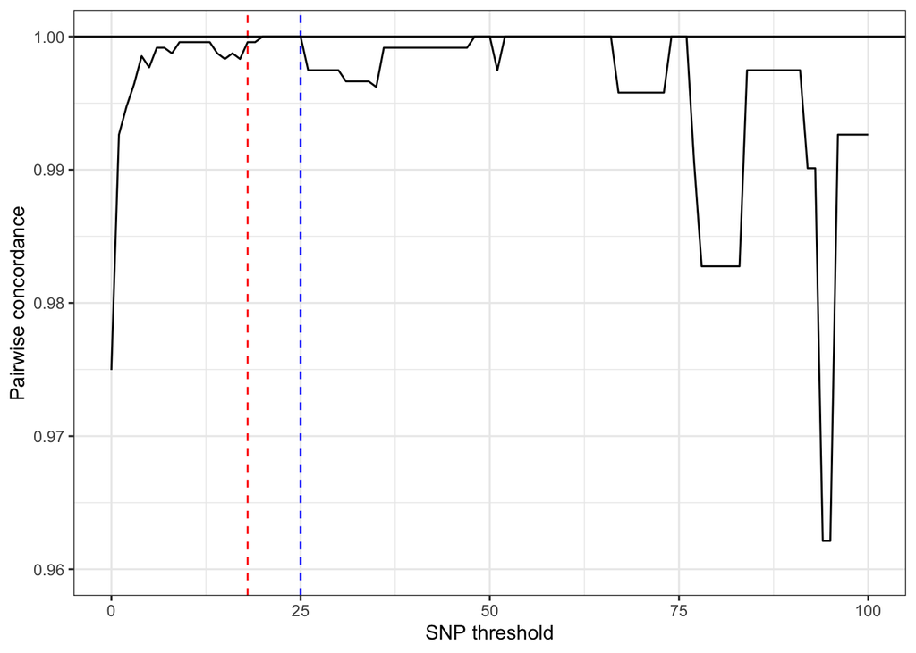

```r
B <- ggplot(data=similarity_dataset_index,aes(x=threshold,y=pairwise_concordance)) + geom_line() + geom_vline(xintercept = 18,linetype = 2,colour = 'red') + geom_vline(xintercept = 25,linetype = 2,colour = 'blue')  + theme_bw() + labs(x='SNP threshold',y='Pairwise concordance') + ylim(0,1.01) +  geom_hline(yintercept = 1) + scale_y_continuous(
  limits = c(lower_pc, 1.0),
  breaks = seq(lower_pc, 1.0, by = 0.01)
)
B
```

```r
paste0("Agreement in clusteirng across variant calling strategies for the index specimens")
```

```
[1] "Agreement in clusteirng across variant calling strategies for the index specimens"
```

```r
similarity_dataset_index %>% select(-isolates) %>% favorite_kable()
```

| threshold | ARI | pairwise_concordance |
| --- | --- | --- |
| 0 | 0.6363664 | 0.9749632 |
| 1 | 0.7962771 | 0.9926362 |
| 2 | 0.8401014 | 0.9947402 |
| 3 | 0.8938860 | 0.9964233 |
| 4 | 0.9568266 | 0.9985272 |
| 5 | 0.9321558 | 0.9976857 |
| 6 | 0.9748808 | 0.9991584 |
| 7 | 0.9748808 | 0.9991584 |
| 8 | 0.9632130 | 0.9987376 |
| 9 | 0.9878811 | 0.9995792 |
| 10 | 0.9878811 | 0.9995792 |
| 11 | 0.9881579 | 0.9995792 |
| 12 | 0.9881579 | 0.9995792 |
| 13 | 0.9881579 | 0.9995792 |
| 14 | 0.9652661 | 0.9987376 |
| 15 | 0.9536881 | 0.9983169 |
| 16 | 0.9656492 | 0.9987376 |
| 17 | 0.9546978 | 0.9983169 |
| 18 | 0.9890327 | 0.9995792 |
| 19 | 0.9890327 | 0.9995792 |
| 20 | 1.0000000 | 1.0000000 |
| 21 | 1.0000000 | 1.0000000 |
| 22 | 1.0000000 | 1.0000000 |
| 23 | 1.0000000 | 1.0000000 |
| 24 | 1.0000000 | 1.0000000 |
| 25 | 1.0000000 | 1.0000000 |
| 26 | 0.9381096 | 0.9974753 |
| 27 | 0.9381096 | 0.9974753 |
| 28 | 0.9381096 | 0.9974753 |
| 29 | 0.9381096 | 0.9974753 |

[output cut: 71 more lines]

# Clustering statistics across index isolates

```r
clustering_across_threshold_index <- pbmclapply(0:100,FUN=function(x){
  old <-cluster_summary_statistics(clustering_across_thresholds_old %>% subset(genomic_id %in% df_index$genomic_id)  %>% .[[paste0("Species_ST_cluster_",x)]]) %>% mutate(type = 'old',threshold=x)
  new <- cluster_summary_statistics(clustering_across_thresholds_ST_preferred %>% subset(genomic_id %in% df_index$genomic_id)  %>% .[[paste0("Species_ST_cluster_",x)]]) %>% mutate(type = 'new',threshold=x)
  rbind.data.frame(old,new )
},mc.cores=15) %>% do.call(rbind,.)

numeric_cols <- c("clusters", "cluster_isolates", "singletons", "percentage_in_cluster",
                  "cluster_size_med", "cluster_size_mean", "cluster_size_max")

old_df_index <- clustering_across_threshold_index %>% filter(type == "old") %>% arrange(threshold)
new_df_index <- clustering_across_threshold_index %>% filter(type == "new") %>% arrange(threshold)

diff_df_index <- new_df_index[numeric_cols] - old_df_index[numeric_cols]
diff_df_index$threshold <- old_df_index$threshold
diff_df_index$type <- "diff (new - old)"
diff_df_index$same_clustering_statistics <- rowSums(abs(diff_df_index[numeric_cols])) == 0
diff_df_index <- diff_df_index %>% select(threshold, same_clustering_statistics, everything())

diff_df_index %>% favorite_kable()
```

| threshold | same_clustering_statistics | clusters | cluster_isolates | singletons | percentage_in_cluster | cluster_size_med | cluster_size_mean | cluster_size_max | type |
| --- | --- | --- | --- | --- | --- | --- | --- | --- | --- |
| 0 | FALSE | 4 | 4 | -4 | 4.081633 | 0 | -0.2125000 | 0 | diff (new - old) |
| 1 | FALSE | 5 | 7 | -7 | 7.142857 | 0 | -0.2236842 | 1 | diff (new - old) |
| 2 | FALSE | 2 | 4 | -4 | 4.081633 | 0 | -0.0662526 | 0 | diff (new - old) |
| 3 | FALSE | 2 | 2 | -2 | 2.040816 | 0 | -0.1656315 | 0 | diff (new - old) |
| 4 | FALSE | 1 | 2 | -2 | 2.040816 | 0 | -0.0326087 | 0 | diff (new - old) |
| 5 | FALSE | -1 | 2 | -2 | 2.040816 | 0 | 0.1950000 | 0 | diff (new - old) |
| 6 | FALSE | -1 | 1 | -1 | 1.020408 | 0 | 0.1461538 | 0 | diff (new - old) |
| 7 | FALSE | -1 | 1 | -1 | 1.020408 | 0 | 0.1461538 | 0 | diff (new - old) |
| 8 | TRUE | 0 | 0 | 0 | 0.000000 | 0 | 0.0000000 | 0 | diff (new - old) |
| 9 | FALSE | 0 | 1 | -1 | 1.020408 | 0 | 0.0400000 | 0 | diff (new - old) |
| 10 | FALSE | 0 | 1 | -1 | 1.020408 | 0 | 0.0400000 | 0 | diff (new - old) |
| 11 | FALSE | 0 | 1 | -1 | 1.020408 | 0 | 0.0400000 | 0 | diff (new - old) |
| 12 | FALSE | 0 | 1 | -1 | 1.020408 | 0 | 0.0400000 | 0 | diff (new - old) |
| 13 | FALSE | 0 | 1 | -1 | 1.020408 | 0 | 0.0400000 | 0 | diff (new - old) |
| 14 | FALSE | 1 | 1 | -1 | 1.020408 | 0 | -0.0783333 | 0 | diff (new - old) |
| 15 | TRUE | 0 | 0 | 0 | 0.000000 | 0 | 0.0000000 | 0 | diff (new - old) |
| 16 | FALSE | 1 | 1 | -1 | 1.020408 | 0 | -0.0753846 | 0 | diff (new - old) |
| 17 | FALSE | 0 | 1 | -1 | 1.020408 | 0 | 0.0400000 | 0 | diff (new - old) |
| 18 | FALSE | 0 | 1 | -1 | 1.020408 | 0 | 0.0416667 | 0 | diff (new - old) |
| 19 | FALSE | 0 | 1 | -1 | 1.020408 | 0 | 0.0416667 | 0 | diff (new - old) |
| 20 | TRUE | 0 | 0 | 0 | 0.000000 | 0 | 0.0000000 | 0 | diff (new - old) |
| 21 | TRUE | 0 | 0 | 0 | 0.000000 | 0 | 0.0000000 | 0 | diff (new - old) |
| 22 | TRUE | 0 | 0 | 0 | 0.000000 | 0 | 0.0000000 | 0 | diff (new - old) |
| 23 | TRUE | 0 | 0 | 0 | 0.000000 | 0 | 0.0000000 | 0 | diff (new - old) |
| 24 | TRUE | 0 | 0 | 0 | 0.000000 | 0 | 0.0000000 | 0 | diff (new - old) |
| 25 | TRUE | 0 | 0 | 0 | 0.000000 | 0 | 0.0000000 | 0 | diff (new - old) |
| 26 | FALSE | 1 | 0 | 0 | 0.000000 | 0 | -0.1358696 | -2 | diff (new - old) |
| 27 | FALSE | 1 | 0 | 0 | 0.000000 | 0 | -0.1358696 | -2 | diff (new - old) |
| 28 | FALSE | 1 | 0 | 0 | 0.000000 | 0 | -0.1358696 | -2 | diff (new - old) |
| 29 | FALSE | 1 | 0 | 0 | 0.000000 | 0 | -0.1358696 | -2 | diff (new - old) |

[output cut: 71 more lines]

# Prolonged colonization at strain level

1. Persistent colonization is the same across old and new at 25 SNPs!
2. Agreement in persistent colonization occurred at 18 SNPs actually

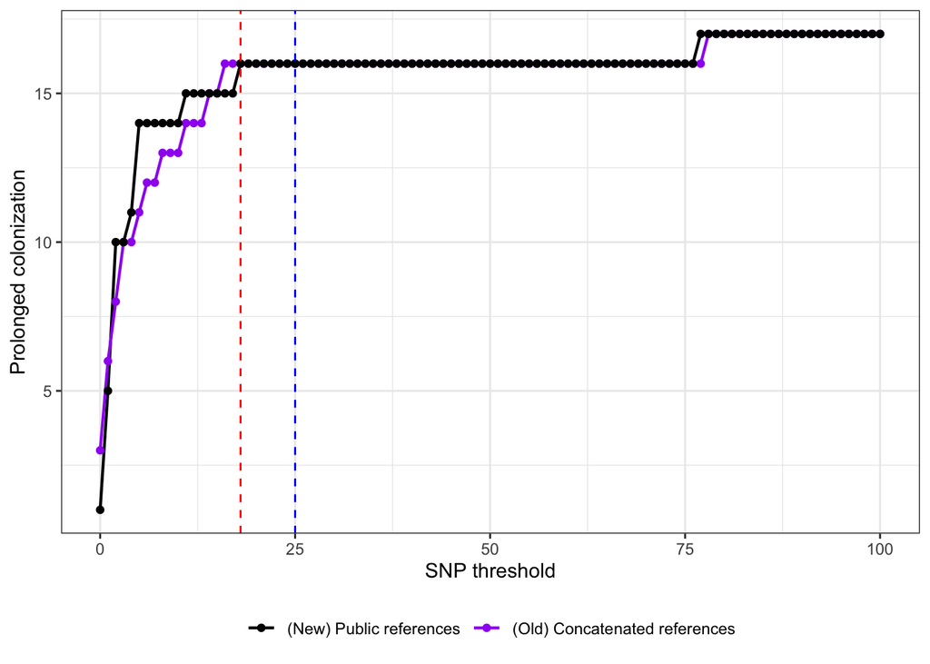

```r
prolonged_colonization_across_thresholds_old<- readRDS("./data/persistent_colonization/deprecated/threshold_sensitivity_strain_level/MERLIN_persistent_colonization_threshold_sensitivity_strain_level_concatenated_references.RDS") %>% mutate(test = "Concatenated references")
  prolonged_colonization_across_thresholds_ST_preferred <- readRDS("./data/persistent_colonization/threshold_sensitivity_strain_level/MERLIN_persistent_colonization_threshold_sensitivity_strain_level_public_references.RDS")%>% mutate(test = "Public references")

summary_data_prolonged <- bind_rows(
    prolonged_colonization_across_thresholds_old %>%
        group_by(threshold) %>%
        summarise(n_events = sum(index_at_1_and_or_2 == 1, na.rm = TRUE)) %>%
        mutate(method = "(Old) Concatenated references"),
    prolonged_colonization_across_thresholds_ST_preferred %>%
        group_by(threshold) %>%
        summarise(n_events = sum(index_at_1_and_or_2 == 1, na.rm = TRUE)) %>%
        mutate(method = "(New) Public references"))

C <-     ggplot(data=summary_data_prolonged,aes(x = threshold, y = n_events, color = method)) +
    geom_line(linewidth = 0.75) +
    geom_point(size = 1.5) +
    scale_color_manual(values = c("(Old) Concatenated references" = "purple", "(New) Public references" = "black")) +
    scale_x_continuous(breaks = seq(0, 100, 25),limits = c(0,100.1)) +
    labs(
        x     = "SNP threshold",
        y     = "Prolonged colonization",
        color = NULL
    )  +
    theme(
        legend.position  = "top",
        legend.justification = "left",
        panel.grid.minor = element_blank()
    ) + geom_vline(xintercept = 18,linetype = 2,colour = 'red') + geom_vline(xintercept = 25,linetype = 2,colour = 'blue') + theme_bw()  + theme(legend.position='bottom')

percent_agreed <- prolonged_colonization_across_thresholds_old %>%
    select(household, threshold, index_at_1_and_or_2) %>%
    rename(index_old = index_at_1_and_or_2) %>%
    left_join(
        prolonged_colonization_across_thresholds_ST_preferred %>%
            select(household, threshold, index_at_1_and_or_2) %>%
            rename(index_new = index_at_1_and_or_2)
    ) %>%
    group_by(threshold) %>%
    summarise(prop_agree = mean(index_old == index_new))

C
```

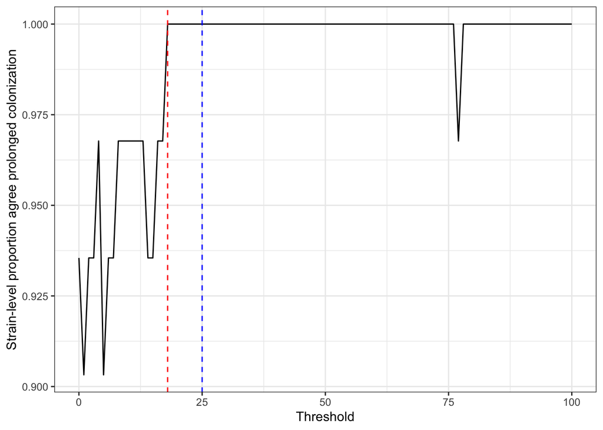

```r
ggplot(data=percent_agreed,aes(x= threshold,y=prop_agree)) + geom_line() + theme_bw() + labs(x="Threshold",y="Strain-level proportion agree prolonged colonization")+ geom_vline(xintercept = 18,linetype = 2,colour = 'red') + geom_vline(xintercept = 25,linetype = 2,colour = 'blue')
```

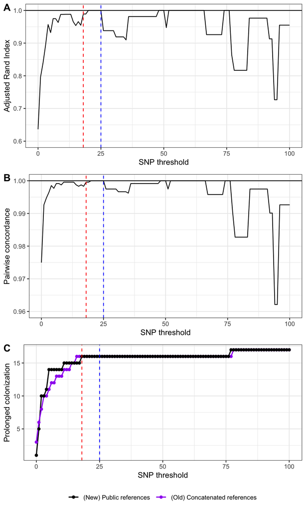

```r
cowplot::plot_grid(A,B,C,ncol=1,labels = "AUTO")
```

# Updating threshold from 25 to a lower number!

1. Given the persistence occurred to coverge at 18 SNPs, we evaluated whether differences existed in clustering patterns across these thresholds to choose a final threshold.
2. We looked at clustering in this dataset, comparing all values to 25 SNP threshold value.

## Clustering in full dataset

1. Plateau in clustering pattern occurred at 18 SNPs to 31 SNPs!
2. Above 31 would merge clusters, which is less desired, especially when found across multiple households!

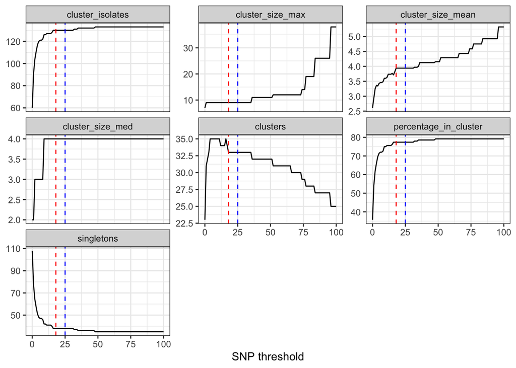

```r
old_twentyfive <- cluster_summary_statistics(
  clustering_across_thresholds_ST_preferred[["Species_ST_cluster_25"]]
) %>% mutate(type = 'old', threshold = 25)

clustering_across_threshold_clustering <- pbmclapply(0:100, FUN = function(x) {
  new_choice <- cluster_summary_statistics(
    clustering_across_thresholds_ST_preferred[[paste0("Species_ST_cluster_", x)]]
  ) %>% mutate(type = 'new', threshold = x)
  rbind.data.frame(old_twentyfive, new_choice)
}, mc.cores = 15) %>% do.call(rbind, .) %>% distinct()

numeric_cols <- c("clusters", "cluster_isolates", "singletons", "percentage_in_cluster",
                  "cluster_size_med", "cluster_size_mean", "cluster_size_max")

clustering_across_threshold_clustering %>%
  filter(type == 'new') %>%
  pivot_longer(cols = all_of(numeric_cols), names_to = "metric", values_to = "value") %>%
  ggplot(aes(x = threshold, y = value)) +
  geom_line() + geom_vline(xintercept = 18,linetype = 2,colour = 'red') + geom_vline(xintercept = 25,linetype = 2,colour = 'blue') +
  facet_wrap(~metric, scales = "free_y", ncol = 3) +
  theme_bw() +
  labs(x = "SNP threshold", y = NULL)
```

```r
ref <- clustering_across_threshold_clustering %>%
  filter(threshold == 25, type == 'new') %>%
  select(all_of(numeric_cols))

threshold_differences <- clustering_across_threshold_clustering %>%
  filter(type == 'new') %>%
  select(threshold, all_of(numeric_cols)) %>%
  left_join(
    clustering_across_threshold_clustering %>%
      filter(threshold == 25, type == 'new') %>%
      select(all_of(numeric_cols)) %>%
      distinct() %>%
      rename_with(~ paste0(.x, "_ref")),
    by = character()
  ) %>%
  mutate(identical_to_25 = if_all(all_of(numeric_cols),
                                   ~ . == get(paste0(cur_column(), "_ref"))))

threshold_differences %>% favorite_kable()
```

| threshold | clusters | cluster_isolates | singletons | percentage_in_cluster | cluster_size_med | cluster_size_mean | cluster_size_max | clusters_ref | cluster_isolates_ref | singletons_ref | percentage_in_cluster_ref | cluster_size_med_ref | cluster_size_mean_ref | cluster_size_max_ref | identical_to_25 |
| --- | --- | --- | --- | --- | --- | --- | --- | --- | --- | --- | --- | --- | --- | --- | --- |
| 0 | 23 | 60 | 108 | 35.71429 | 2 | 2.608696 | 7 | 33 | 130 | 38 | 77.38095 | 4 | 3.939394 | 9 | FALSE |
| 1 | 31 | 91 | 77 | 54.16667 | 2 | 2.935484 | 9 | 33 | 130 | 38 | 77.38095 | 4 | 3.939394 | 9 | FALSE |
| 2 | 32 | 104 | 64 | 61.90476 | 3 | 3.250000 | 9 | 33 | 130 | 38 | 77.38095 | 4 | 3.939394 | 9 | FALSE |
| 3 | 33 | 111 | 57 | 66.07143 | 3 | 3.363636 | 9 | 33 | 130 | 38 | 77.38095 | 4 | 3.939394 | 9 | FALSE |
| 4 | 35 | 117 | 51 | 69.64286 | 3 | 3.342857 | 9 | 33 | 130 | 38 | 77.38095 | 4 | 3.939394 | 9 | FALSE |
| 5 | 35 | 120 | 48 | 71.42857 | 3 | 3.428571 | 9 | 33 | 130 | 38 | 77.38095 | 4 | 3.939394 | 9 | FALSE |
| 6 | 35 | 121 | 47 | 72.02381 | 3 | 3.457143 | 9 | 33 | 130 | 38 | 77.38095 | 4 | 3.939394 | 9 | FALSE |
| 7 | 35 | 121 | 47 | 72.02381 | 3 | 3.457143 | 9 | 33 | 130 | 38 | 77.38095 | 4 | 3.939394 | 9 | FALSE |
| 8 | 35 | 122 | 46 | 72.61905 | 3 | 3.485714 | 9 | 33 | 130 | 38 | 77.38095 | 4 | 3.939394 | 9 | FALSE |
| 9 | 35 | 126 | 42 | 75.00000 | 4 | 3.600000 | 9 | 33 | 130 | 38 | 77.38095 | 4 | 3.939394 | 9 | FALSE |
| 10 | 35 | 126 | 42 | 75.00000 | 4 | 3.600000 | 9 | 33 | 130 | 38 | 77.38095 | 4 | 3.939394 | 9 | FALSE |
| 11 | 35 | 127 | 41 | 75.59524 | 4 | 3.628571 | 9 | 33 | 130 | 38 | 77.38095 | 4 | 3.939394 | 9 | FALSE |
| 12 | 34 | 127 | 41 | 75.59524 | 4 | 3.735294 | 9 | 33 | 130 | 38 | 77.38095 | 4 | 3.939394 | 9 | FALSE |
| 13 | 34 | 127 | 41 | 75.59524 | 4 | 3.735294 | 9 | 33 | 130 | 38 | 77.38095 | 4 | 3.939394 | 9 | FALSE |
| 14 | 34 | 127 | 41 | 75.59524 | 4 | 3.735294 | 9 | 33 | 130 | 38 | 77.38095 | 4 | 3.939394 | 9 | FALSE |
| 15 | 34 | 128 | 40 | 76.19048 | 4 | 3.764706 | 9 | 33 | 130 | 38 | 77.38095 | 4 | 3.939394 | 9 | FALSE |
| 16 | 35 | 130 | 38 | 77.38095 | 4 | 3.714286 | 9 | 33 | 130 | 38 | 77.38095 | 4 | 3.939394 | 9 | FALSE |
| 17 | 34 | 130 | 38 | 77.38095 | 4 | 3.823529 | 9 | 33 | 130 | 38 | 77.38095 | 4 | 3.939394 | 9 | FALSE |
| 18 | 33 | 130 | 38 | 77.38095 | 4 | 3.939394 | 9 | 33 | 130 | 38 | 77.38095 | 4 | 3.939394 | 9 | TRUE |
| 19 | 33 | 130 | 38 | 77.38095 | 4 | 3.939394 | 9 | 33 | 130 | 38 | 77.38095 | 4 | 3.939394 | 9 | TRUE |
| 20 | 33 | 130 | 38 | 77.38095 | 4 | 3.939394 | 9 | 33 | 130 | 38 | 77.38095 | 4 | 3.939394 | 9 | TRUE |
| 21 | 33 | 130 | 38 | 77.38095 | 4 | 3.939394 | 9 | 33 | 130 | 38 | 77.38095 | 4 | 3.939394 | 9 | TRUE |
| 22 | 33 | 130 | 38 | 77.38095 | 4 | 3.939394 | 9 | 33 | 130 | 38 | 77.38095 | 4 | 3.939394 | 9 | TRUE |
| 23 | 33 | 130 | 38 | 77.38095 | 4 | 3.939394 | 9 | 33 | 130 | 38 | 77.38095 | 4 | 3.939394 | 9 | TRUE |
| 24 | 33 | 130 | 38 | 77.38095 | 4 | 3.939394 | 9 | 33 | 130 | 38 | 77.38095 | 4 | 3.939394 | 9 | TRUE |
| 25 | 33 | 130 | 38 | 77.38095 | 4 | 3.939394 | 9 | 33 | 130 | 38 | 77.38095 | 4 | 3.939394 | 9 | TRUE |
| 26 | 33 | 130 | 38 | 77.38095 | 4 | 3.939394 | 9 | 33 | 130 | 38 | 77.38095 | 4 | 3.939394 | 9 | TRUE |
| 27 | 33 | 130 | 38 | 77.38095 | 4 | 3.939394 | 9 | 33 | 130 | 38 | 77.38095 | 4 | 3.939394 | 9 | TRUE |
| 28 | 33 | 130 | 38 | 77.38095 | 4 | 3.939394 | 9 | 33 | 130 | 38 | 77.38095 | 4 | 3.939394 | 9 | TRUE |
| 29 | 33 | 130 | 38 | 77.38095 | 4 | 3.939394 | 9 | 33 | 130 | 38 | 77.38095 | 4 | 3.939394 | 9 | TRUE |

[output cut: 71 more lines]

```r
paste0("Lowest threshold with same clustering statistics as 25 SNPs: ",threshold_differences %>% subset(identical_to_25==T) %>% .$threshold %>% min())
```

```
[1] "Lowest threshold with same clustering statistics as 25 SNPs: 18"
```

## Clustering patterns among index cases

1. Clustering plateaus from 18 SNP to 31 SNPs, like in the full dataset!

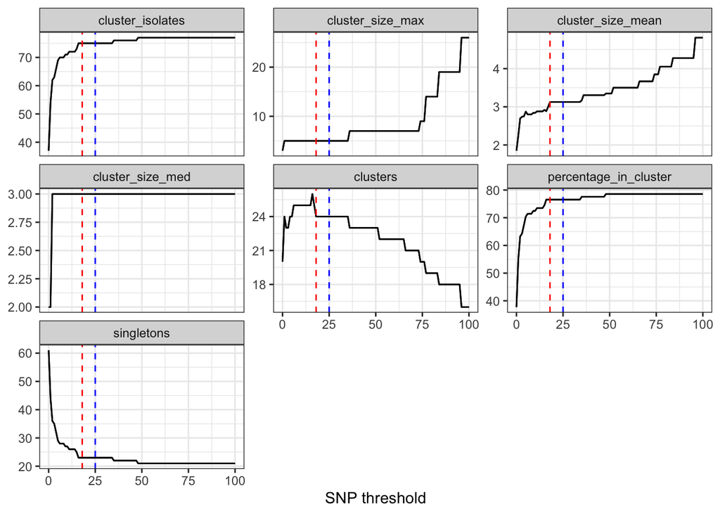

```r
old_twentyfive_index <- cluster_summary_statistics(
  clustering_across_thresholds_ST_preferred %>% subset(genomic_id %in% df_index$genomic_id) %>% .[["Species_ST_cluster_25"]]
) %>% mutate(type = 'old', threshold = 25)

clustering_across_threshold_clustering_index <- pbmclapply(0:100, FUN = function(x) {
  new_choice <- cluster_summary_statistics(
    clustering_across_thresholds_ST_preferred %>% subset(genomic_id %in% df_index$genomic_id) %>%  .[[paste0("Species_ST_cluster_", x)]]
  ) %>% mutate(type = 'new', threshold = x)
  rbind.data.frame(old_twentyfive_index, new_choice)
}, mc.cores = 15) %>% do.call(rbind, .) %>% distinct()

numeric_cols <- c("clusters", "cluster_isolates", "singletons", "percentage_in_cluster",
                  "cluster_size_med", "cluster_size_mean", "cluster_size_max")

clustering_across_threshold_clustering_index %>%
  filter(type == 'new') %>%
  pivot_longer(cols = all_of(numeric_cols), names_to = "metric", values_to = "value") %>%
  ggplot(aes(x = threshold, y = value)) +
  geom_line() +
  geom_line() + geom_vline(xintercept = 18,linetype = 2,colour = 'red') + geom_vline(xintercept = 25,linetype = 2,colour = 'blue')+
  facet_wrap(~metric, scales = "free_y", ncol = 3) +
  theme_bw() +
  labs(x = "SNP threshold", y = NULL)
```

```r
ref <- clustering_across_threshold_clustering %>%
  filter(threshold == 25, type == 'new') %>%
  select(all_of(numeric_cols))

threshold_differences <- clustering_across_threshold_clustering %>%
  filter(type == 'new') %>%
  select(threshold, all_of(numeric_cols)) %>%
  left_join(
    clustering_across_threshold_clustering %>%
      filter(threshold == 25, type == 'new') %>%
      select(all_of(numeric_cols)) %>%
      distinct() %>%
      rename_with(~ paste0(.x, "_ref")),
    by = character()
  ) %>%
  mutate(identical_to_25 = if_all(all_of(numeric_cols),
                                   ~ . == get(paste0(cur_column(), "_ref"))))

threshold_differences %>% favorite_kable()
```

| threshold | clusters | cluster_isolates | singletons | percentage_in_cluster | cluster_size_med | cluster_size_mean | cluster_size_max | clusters_ref | cluster_isolates_ref | singletons_ref | percentage_in_cluster_ref | cluster_size_med_ref | cluster_size_mean_ref | cluster_size_max_ref | identical_to_25 |
| --- | --- | --- | --- | --- | --- | --- | --- | --- | --- | --- | --- | --- | --- | --- | --- |
| 0 | 23 | 60 | 108 | 35.71429 | 2 | 2.608696 | 7 | 33 | 130 | 38 | 77.38095 | 4 | 3.939394 | 9 | FALSE |
| 1 | 31 | 91 | 77 | 54.16667 | 2 | 2.935484 | 9 | 33 | 130 | 38 | 77.38095 | 4 | 3.939394 | 9 | FALSE |
| 2 | 32 | 104 | 64 | 61.90476 | 3 | 3.250000 | 9 | 33 | 130 | 38 | 77.38095 | 4 | 3.939394 | 9 | FALSE |
| 3 | 33 | 111 | 57 | 66.07143 | 3 | 3.363636 | 9 | 33 | 130 | 38 | 77.38095 | 4 | 3.939394 | 9 | FALSE |
| 4 | 35 | 117 | 51 | 69.64286 | 3 | 3.342857 | 9 | 33 | 130 | 38 | 77.38095 | 4 | 3.939394 | 9 | FALSE |
| 5 | 35 | 120 | 48 | 71.42857 | 3 | 3.428571 | 9 | 33 | 130 | 38 | 77.38095 | 4 | 3.939394 | 9 | FALSE |
| 6 | 35 | 121 | 47 | 72.02381 | 3 | 3.457143 | 9 | 33 | 130 | 38 | 77.38095 | 4 | 3.939394 | 9 | FALSE |
| 7 | 35 | 121 | 47 | 72.02381 | 3 | 3.457143 | 9 | 33 | 130 | 38 | 77.38095 | 4 | 3.939394 | 9 | FALSE |
| 8 | 35 | 122 | 46 | 72.61905 | 3 | 3.485714 | 9 | 33 | 130 | 38 | 77.38095 | 4 | 3.939394 | 9 | FALSE |
| 9 | 35 | 126 | 42 | 75.00000 | 4 | 3.600000 | 9 | 33 | 130 | 38 | 77.38095 | 4 | 3.939394 | 9 | FALSE |
| 10 | 35 | 126 | 42 | 75.00000 | 4 | 3.600000 | 9 | 33 | 130 | 38 | 77.38095 | 4 | 3.939394 | 9 | FALSE |
| 11 | 35 | 127 | 41 | 75.59524 | 4 | 3.628571 | 9 | 33 | 130 | 38 | 77.38095 | 4 | 3.939394 | 9 | FALSE |
| 12 | 34 | 127 | 41 | 75.59524 | 4 | 3.735294 | 9 | 33 | 130 | 38 | 77.38095 | 4 | 3.939394 | 9 | FALSE |
| 13 | 34 | 127 | 41 | 75.59524 | 4 | 3.735294 | 9 | 33 | 130 | 38 | 77.38095 | 4 | 3.939394 | 9 | FALSE |
| 14 | 34 | 127 | 41 | 75.59524 | 4 | 3.735294 | 9 | 33 | 130 | 38 | 77.38095 | 4 | 3.939394 | 9 | FALSE |
| 15 | 34 | 128 | 40 | 76.19048 | 4 | 3.764706 | 9 | 33 | 130 | 38 | 77.38095 | 4 | 3.939394 | 9 | FALSE |
| 16 | 35 | 130 | 38 | 77.38095 | 4 | 3.714286 | 9 | 33 | 130 | 38 | 77.38095 | 4 | 3.939394 | 9 | FALSE |
| 17 | 34 | 130 | 38 | 77.38095 | 4 | 3.823529 | 9 | 33 | 130 | 38 | 77.38095 | 4 | 3.939394 | 9 | FALSE |
| 18 | 33 | 130 | 38 | 77.38095 | 4 | 3.939394 | 9 | 33 | 130 | 38 | 77.38095 | 4 | 3.939394 | 9 | TRUE |
| 19 | 33 | 130 | 38 | 77.38095 | 4 | 3.939394 | 9 | 33 | 130 | 38 | 77.38095 | 4 | 3.939394 | 9 | TRUE |
| 20 | 33 | 130 | 38 | 77.38095 | 4 | 3.939394 | 9 | 33 | 130 | 38 | 77.38095 | 4 | 3.939394 | 9 | TRUE |
| 21 | 33 | 130 | 38 | 77.38095 | 4 | 3.939394 | 9 | 33 | 130 | 38 | 77.38095 | 4 | 3.939394 | 9 | TRUE |
| 22 | 33 | 130 | 38 | 77.38095 | 4 | 3.939394 | 9 | 33 | 130 | 38 | 77.38095 | 4 | 3.939394 | 9 | TRUE |
| 23 | 33 | 130 | 38 | 77.38095 | 4 | 3.939394 | 9 | 33 | 130 | 38 | 77.38095 | 4 | 3.939394 | 9 | TRUE |
| 24 | 33 | 130 | 38 | 77.38095 | 4 | 3.939394 | 9 | 33 | 130 | 38 | 77.38095 | 4 | 3.939394 | 9 | TRUE |
| 25 | 33 | 130 | 38 | 77.38095 | 4 | 3.939394 | 9 | 33 | 130 | 38 | 77.38095 | 4 | 3.939394 | 9 | TRUE |
| 26 | 33 | 130 | 38 | 77.38095 | 4 | 3.939394 | 9 | 33 | 130 | 38 | 77.38095 | 4 | 3.939394 | 9 | TRUE |
| 27 | 33 | 130 | 38 | 77.38095 | 4 | 3.939394 | 9 | 33 | 130 | 38 | 77.38095 | 4 | 3.939394 | 9 | TRUE |
| 28 | 33 | 130 | 38 | 77.38095 | 4 | 3.939394 | 9 | 33 | 130 | 38 | 77.38095 | 4 | 3.939394 | 9 | TRUE |
| 29 | 33 | 130 | 38 | 77.38095 | 4 | 3.939394 | 9 | 33 | 130 | 38 | 77.38095 | 4 | 3.939394 | 9 | TRUE |

[output cut: 71 more lines]

```r
paste0("Lowest threshold with same clustering statistics: ",threshold_differences %>% subset(identical_to_25==T) %>% .$threshold %>% min())
```

```
[1] "Lowest threshold with same clustering statistics: 18"
```

## Persistent colonization events in index cases in the new dataset across different thresholds

1. Same persistence calls from 18 SNPs to 76 SNPs, making presistent appear relatively really stable in this population, making it seem advantageous to choose 18 SNP threshold (at a minimum).

```r
summary_data_prolonged %>% subset(method =="(New) Public references") %>% favorite_kable()
```

| threshold | n_events | method |
| --- | --- | --- |
| 0 | 1 | (New) Public references |
| 1 | 5 | (New) Public references |
| 2 | 10 | (New) Public references |
| 3 | 10 | (New) Public references |
| 4 | 11 | (New) Public references |
| 5 | 14 | (New) Public references |
| 6 | 14 | (New) Public references |
| 7 | 14 | (New) Public references |
| 8 | 14 | (New) Public references |
| 9 | 14 | (New) Public references |
| 10 | 14 | (New) Public references |
| 11 | 15 | (New) Public references |
| 12 | 15 | (New) Public references |
| 13 | 15 | (New) Public references |
| 14 | 15 | (New) Public references |
| 15 | 15 | (New) Public references |
| 16 | 15 | (New) Public references |
| 17 | 15 | (New) Public references |
| 18 | 16 | (New) Public references |
| 19 | 16 | (New) Public references |
| 20 | 16 | (New) Public references |
| 21 | 16 | (New) Public references |
| 22 | 16 | (New) Public references |
| 23 | 16 | (New) Public references |
| 24 | 16 | (New) Public references |
| 25 | 16 | (New) Public references |
| 26 | 16 | (New) Public references |
| 27 | 16 | (New) Public references |
| 28 | 16 | (New) Public references |
| 29 | 16 | (New) Public references |

[output cut: 71 more lines]

```r
paste0("Lowest threshold value with same value as 25 SNP threshold: ",
summary_data_prolonged %>% subset(method =="(New) Public references") %>% subset(n_events ==

                                                                                     summary_data_prolonged %>% subset(method =="(New) Public references" & threshold==25) %>% .$n_events  ) %>% .$threshold %>% min)
```

```
[1] "Lowest threshold value with same value as 25 SNP threshold: 18"
```

## Lowest pairwise clustering and ARI values with purity and similarity to 25 SNP threshold from initial submission among full dataset

1. ARI and pairwise concordance plateaus from 18 to 31 SNPs!
2. This extends to index specimens, so we’re doing fine!

```r
ref_col <- "Species_ST_cluster_25"
ref_clusters_full <- clustering_across_thresholds_ST_preferred %>%
  select(genomic_id, all_of(ref_col))

similarity_dataset_new_threshold_choice_to_25_SNP_threshold <- lapply(0:100, FUN = function(x) {
  col_name <- paste0("Species_ST_cluster_", x)

  SNP_clustering <- clustering_across_thresholds_ST_preferred %>%
    select(genomic_id, all_of(col_name)) %>%
    left_join(ref_clusters_full, by = "genomic_id")

  test_clusters <- SNP_clustering[[col_name]]
  ref_clusters  <- SNP_clustering[[ref_col]]

  co_cluster_test <- outer(test_clusters, test_clusters, "==")
  co_cluster_ref  <- outer(ref_clusters,  ref_clusters,  "==")
  pair_concordance <- mean((co_cluster_test == co_cluster_ref)[lower.tri(co_cluster_test)])

  data.frame(
    threshold            = x,
    ARI                  = mclust::adjustedRandIndex(test_clusters, ref_clusters),
    pairwise_concordance = pair_concordance,
    isolates             = nrow(SNP_clustering)
  )
}) %>%
  bind_rows()


similarity_dataset_new_threshold_choice_to_25_SNP_threshold %>% favorite_kable()
```

[output not shown]

[output cut: 71 more lines]

```r
paste0("Lowest threshold with identical clustering: ",
similarity_dataset_new_threshold_choice_to_25_SNP_threshold %>% subset(ARI==1 & pairwise_concordance ==1) %>% .$threshold %>% min)
```

```
[1] "Lowest threshold with identical clustering: 18"
```

# What is going on in the weird households approaching the SNP threshol?

```r
make_household_heatmap <- function(household_df, snp_mat, title, clustering_df) {
    household_df <- household_df %>%
        left_join(clustering_df %>% select(genomic_id, Species_ST_cluster_15, Species_ST_cluster_16, Species_ST_cluster_17, Species_ST_cluster_18),
                  by = "genomic_id") %>%
        filter(genomic_id %in% rownames(snp_mat))

    household_df <- household_df[match(rownames(snp_mat)[rownames(snp_mat) %in% household_df$genomic_id], household_df$genomic_id), ]

    ids <- household_df$genomic_id
    mat <- snp_mat[ids, ids]
    d   <- stats::as.dist(mat)

    ha <- ComplexHeatmap::HeatmapAnnotation(
        Visit      = as.character(household_df$visit),
        Host       = household_df$subject_category_simplified,
        Cluster_15 = as.character(household_df$Species_ST_cluster_15),
        Cluster_16 = as.character(household_df$Species_ST_cluster_16),
        Cluster_17 = as.character(household_df$Species_ST_cluster_17),
        Cluster_18 = as.character(household_df$Species_ST_cluster_18)
    )

    ComplexHeatmap::Heatmap(
        mat,
        name                        = "SNP distance",
        top_annotation              = ha,
        col                         = circlize::colorRamp2(c(0, max(mat, na.rm = TRUE)), c("white", "darkred")),
        row_labels                  = household_df$genomic_id,
        column_labels               = household_df$genomic_id,
        cluster_rows                = TRUE,
        cluster_columns             = TRUE,
        clustering_distance_rows    = d,
        clustering_distance_columns = d,
        row_dend_reorder            = FALSE,
        column_dend_reorder         = FALSE,
        column_title                = title,
        row_names_gp                = grid::gpar(fontsize = 7),
        column_names_gp             = grid::gpar(fontsize = 7),
        cell_fun = function(j, i, x, y, width, height, fill) {
            grid::grid.text(mat[i, j], x, y, gp = grid::gpar(fontsize = 7))
        }
    )
}
```

## Load data

```r
SNP_matrices <- readRDS("./data/SNP_distances/SNP_distance_matrices/MERLIN_SNP_distance_matrices_public_references.RDS")
amrfinder_mat <- readRDS("./data/amrfinder/amrfinder_matrix.RDS") %>% subset(rownames(.) %in% df$genomic_id) %>% select_if(colSums(.)>0)
amrfinder <- readRDS("./data/amrfinder/amrfinder_cleaned.RDS")  %>% subset(element_symbol_renamed %in% colnames(amrfinder_mat))
ESCrE_genotype_info <- readRDS("./data/amrfinder/beta_lactamase_summary_MERLIN_cohort.RDS")  %>% subset(element_symbol_renamed %in% colnames(amrfinder_mat))
ESCRE_genotypes <- ESCrE_genotype_info %>% subset(ESCrE==T) %>% .$element_symbol_renamed
mobsuite_gene_pres <- readRDS("./data/ESBL_plasmids/amrfinder_mobsuite_beta_lactamase_presence.RDS") %>% subset(genomic_id %in% df$genomic_id)
ESCrE_plasmid_clusters <- readRDS("./data/ESBL_plasmids/amrfinder_ESCrE_contig_matrix.RDS") %>% subset(rownames(.) %in% df$genomic_id) %>% select_if(colSums(.)>0)
mobsuite_matrix <- readRDS("./data/mobsuite/plasmid_cluster_matrix.RDS")

# Species specific
kpn_mat <- SNP_matrices$kpneumoniae_ST15
ecoli_mat <- SNP_matrices$ecoli_ST131
ecoli_mat_ST38 <- SNP_matrices$ecoli_ST38
```

## 130H - Two populations, but under a relevant threshold.

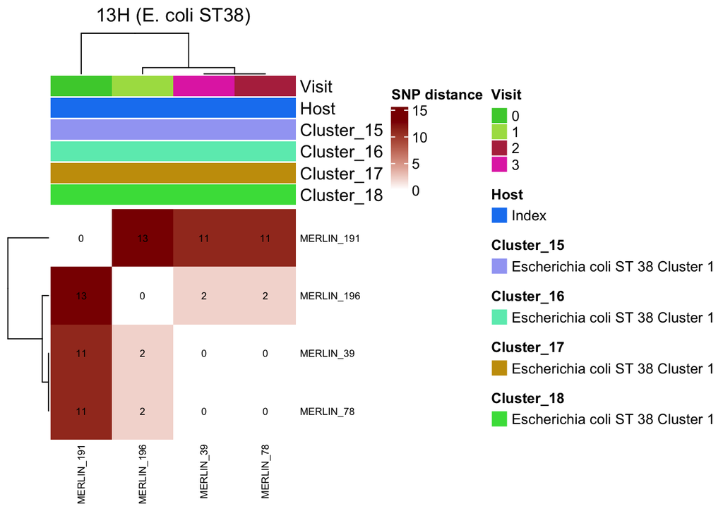

```r
# Data
H130 <- subset(df,household=="130H" & Species_ST == "Escherichia coli ST 38")
# Heatmap
H130_heatmap <- make_household_heatmap(H130, ecoli_mat_ST38, "13H (E. coli ST38)", clustering_across_thresholds_ST_preferred)
H130_heatmap
```

```r
# AMRFinder plus
H130_amrfinder <- amrfinder_mat   %>% subset(rownames(.) %in% H130$genomic_id) %>% select(ESCRE_genotypes) %>% select_if(colSums(.)>0)
H130_amrfinder
```

```
           blaCMY-4 blaCTX-M-15 blaEC-8*
MERLIN_196        1           1        1
MERLIN_39         1           1        1
MERLIN_78         1           1        1
MERLIN_191        0           1        1
```

```r
# Mobsuite data
H130_mobsuite_mat <- mobsuite_matrix %>% subset(rownames(.) %in%H130$genomic_id)
H130_mobsuite_mat %>% select_if(colSums(.)>0)
```

```
           AA579 AB685 AA372 AA142 AA282 AC741
MERLIN_196     1     1     0     0     1     1
MERLIN_39      1     1     0     1     1     1
MERLIN_78      1     1     0     0     1     0
MERLIN_191     1     1     1     1     0     0
```

```r
# ESCrE plasmids
H130_mobsuite <- ESCrE_plasmid_clusters %>% subset(rownames(.) %in%H130$genomic_id)
H130_mobsuite %>% select_if(colSums(.)>0)
```

```
           chromosome AA372 AA282
MERLIN_196          1     0     1
MERLIN_39           1     0     1
MERLIN_78           1     0     1
MERLIN_191          1     1     0
```

## 320H - ST131 lineage. Possible that there are sublineages, but this might reflect intra-host diversity or a shared reservoir or co-colonization or single isolate sequencing bias

1. Two or three smaller lineages, likely evidence of intra host evolution and a bath reservoir
2. Genotye data is similar, so likely a persistent strain in the household

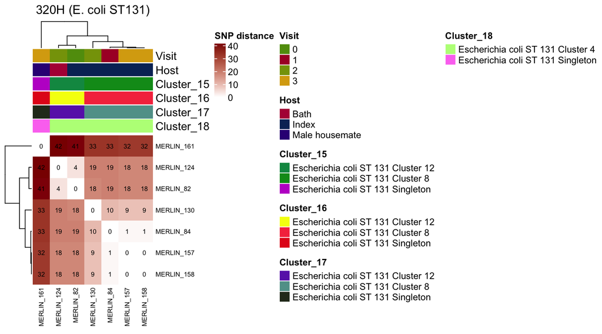

```r
# Data
H320 <- subset(df,household=="320H" & Species_ST == "Escherichia coli ST 131")
# Heatmap
H320_heatmap <- make_household_heatmap(H320, ecoli_mat, "320H (E. coli ST131)", clustering_across_thresholds_ST_preferred)
H320_heatmap
```

```r
# AMRFinder plus
H320_amrfinder <- amrfinder_mat   %>% subset(rownames(.) %in% H320$genomic_id) %>% select(ESCRE_genotypes) %>% select_if(colSums(.)>0)
H320_amrfinder
```

```
           blaCTX-M-15 blaEC-5*
MERLIN_84            1        1
MERLIN_130           1        1
MERLIN_124           1        1
MERLIN_158           1        1
MERLIN_157           1        1
MERLIN_161           1        1
MERLIN_82            1        1
```

```r
# Mobsuite data
H320_mobsuite_mat <- mobsuite_matrix %>% subset(rownames(.) %in%H320$genomic_id)
H320_mobsuite_mat %>% select_if(colSums(.)>0)
```

```
           AA337 AA336
MERLIN_84      1     0
MERLIN_130     1     0
MERLIN_124     1     0
MERLIN_158     1     0
MERLIN_157     1     0
MERLIN_161     0     1
MERLIN_82      1     0
```

```r
# ESCrE plasmids
H320_mobsuite <- ESCrE_plasmid_clusters %>% subset(rownames(.) %in%H320$genomic_id)
H320_mobsuite %>% select_if(colSums(.)>0)
```

```
           chromosome
MERLIN_84           1
MERLIN_130          1
MERLIN_124          1
MERLIN_158          1
MERLIN_157          1
MERLIN_161          1
MERLIN_82           1
```

## 445H - Similar conclusion to 320H

1. Three internal lineages, but with intra-group distance being tight (e.g., 0-5, 0-1, and 0-2) and across-group being variable (17-22, 9-22, and 9-18), we can also argue multiple host micro-evolution or circulating persistent lineage (4 hosts afterall!)
2. Still, a dominant genotype is found, so less concerned!

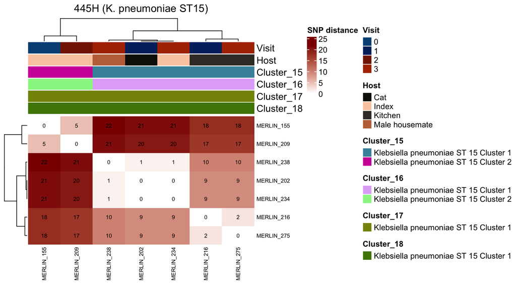

```r
# Data
H445 <-  subset(df,household=="445H" & Species_ST == "Klebsiella pneumoniae ST 15")
# Heatmap
H445_heatmap <- make_household_heatmap(H445, kpn_mat,   "445H (K. pneumoniae ST15)", clustering_across_thresholds_ST_preferred)
H445_heatmap
```

```r
# AMRFinderPlus
H445_amrfinder <- amrfinder_mat   %>% subset(rownames(.) %in% H445$genomic_id) %>% select(ESCRE_genotypes) %>% select_if(colSums(.)>0)
H445_amrfinder
```

```
           blaCTX-M-15
MERLIN_216           1
MERLIN_202           1
MERLIN_209           1
MERLIN_234           1
MERLIN_238           1
MERLIN_275           1
MERLIN_155           1
```

```r
# Mobsuite matrix
H445_mobsuite_mat <- mobsuite_matrix %>% subset(rownames(.) %in%H445$genomic_id)
H445_mobsuite_mat %>% select_if(colSums(.)>0)
```

```
           AA277 AB687 AA024 AA810 AG600 novel_c4cbcd9229542950b70cf3873d91ead5
MERLIN_216     1     1     1     1     1                                      0
MERLIN_202     1     1     0     0     0                                      0
MERLIN_209     1     1     0     0     1                                      0
MERLIN_234     0     1     0     0     0                                      0
MERLIN_238     1     1     0     0     0                                      0
MERLIN_275     1     1     1     1     1                                      0
MERLIN_155     1     1     1     1     1                                      1
           AD092 AA450 AA452 novel_9f529d84059a944637de96bbfdaa16d1 AA554
MERLIN_216     1     0     0                                      1     0
MERLIN_202     0     1     0                                      0     0
MERLIN_209     0     0     1                                      0     0
MERLIN_234     0     1     0                                      0     1
MERLIN_238     0     1     0                                      0     0
MERLIN_275     1     0     0                                      0     0
MERLIN_155     1     0     0                                      0     0
```

```r
# ESCrE plasmids
H445_mobsuite <- ESCrE_plasmid_clusters %>% subset(rownames(.) %in%H445$genomic_id)
H445_mobsuite %>% select_if(colSums(.)>0)
```

```
           AA277 AA452 AA554
MERLIN_216     1     0     0
MERLIN_202     1     0     0
MERLIN_209     0     1     0
MERLIN_234     0     0     1
MERLIN_238     1     0     0
MERLIN_275     1     0     0
MERLIN_155     1     0     0
```